# CSCI E-63C: Final Exam

## Problem 6b: make predictions for the **test** dataset (3 points)

> Decide on the model that performs the best and use it to make predictions for the **test** dataset. This is the dataset that is provided separately from training data without the outcome `yn` that we are modeling here. Upload resulting predictions in comma-separated values (CSV) format into the Canvas website. Please check sample files with test dataset predictions for the expected format of the *.csv file with predictions.

Before trying a prediction, let’s take one last look at the random forest using some additional data from the factor columns and interaction terms discovered using logistic regression methods.

```r
rfFit <- randomForest(select(moreData, -yn), moreData$yn)
```

```r
smallSample <- moreData[sample(1:nrow(moreData), nrow(moreData) / 5, replace = TRUE), ]

tune.rf <- tuneRF(select(smallSample, -yn), smallSample$yn,
                  mtryStart = 30, improve = 0, stepFactor = 1.5)
```

```
## mtry = 30  OOB error = 6.92%
## Searching left ...
## mtry = 20    OOB error = 7.14%
## -0.03194103 0
## Searching right ...
## mtry = 45    OOB error = 6.54%
## 0.05405405 0
## mtry = 66    OOB error = 6.9%
## -0.05454545 0
```

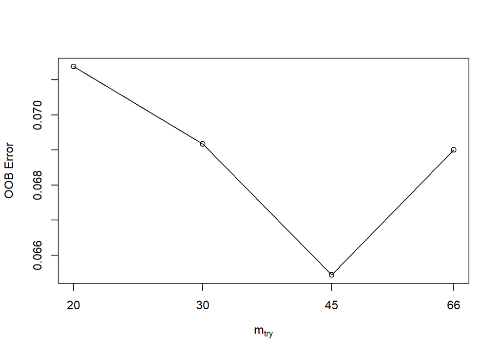

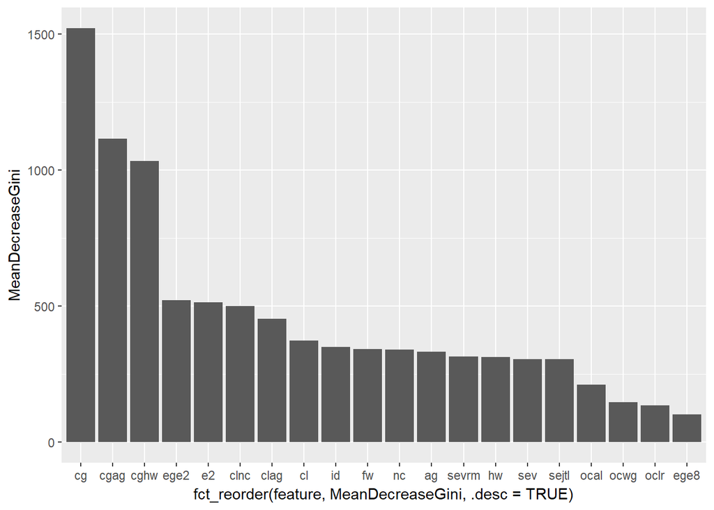

```r
rfFit$importance %>% as.tibble(rownames = "feature") %>%
  arrange(desc(MeanDecreaseGini)) %>%
  head(20) %>%
  ggplot(aes(x = fct_reorder(feature, MeanDecreaseGini, .desc = TRUE), y = MeanDecreaseGini)) +
  geom_col()
```

```r
k <- 10
kfInd <- sample(rep(c(1:k),length.out=nrow(moreData)))
xvalResultsRFM <- tibble()

for (fold in 1:k) {
  trainDataFit <- moreData[kfInd != fold, ]
  trainDataVal <- moreData[kfInd == fold, ]

  rfmFit <- randomForest(select(trainDataFit, -yn), trainDataFit$yn, mtry = 30)

  rfmPredict <- predict(rfmFit, newdata = select(trainDataVal, -yn))
  rfmCM <- table(trainDataVal$yn, rfmPredict)

  xvalResultsRFM <- rbind(xvalResultsRFM, tibble(
    fold = fold,
    acc = calcAcc(rfmCM),
    sens = calcSensitivity(rfmCM),
    spec = calcSpecificity(rfmCM),
    model = "rf-m"
  ))
}
```

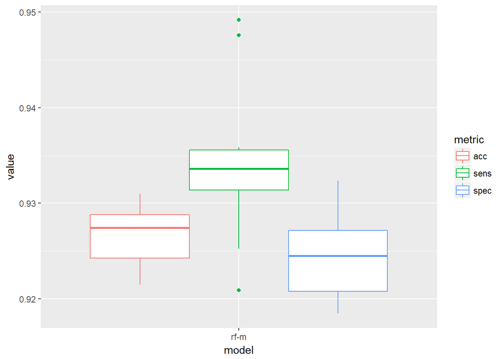

```r
xvalResultsRFM %>% gather(key = metric, value = value, -c(fold, model)) %>%
  ggplot(aes(x = model, y = value, col = metric)) + geom_boxplot()
```

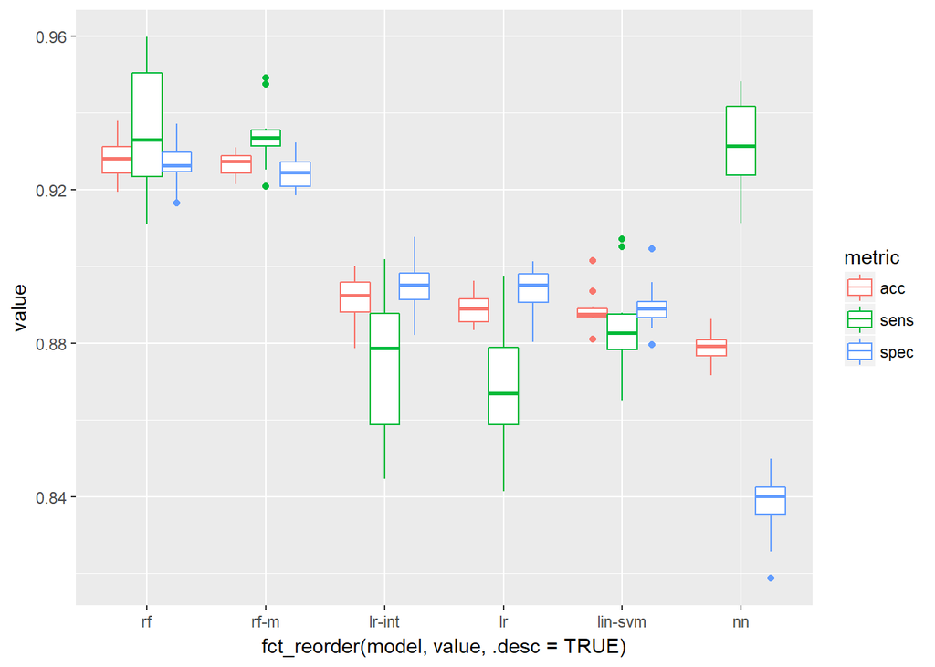

```r
xvalResults <- bind_rows(
  xvalResultsLR,
  xvalResultsLRInt,
  xvalResultsRF,
  xvalResultsRFM,
  xvalResultsSVM,
  xvalResultsNN
)

xvalResults %>% gather(key = metric, value = value, -c(fold, model)) %>%
  ggplot(aes(x = fct_reorder(model, value, .desc = TRUE), y = value, col = metric)) +
  geom_boxplot()
```

It appears that the random forest without extra data still performs the best. With that settled, let’s make some predictions.

```r
rawTestData <- read_csv("final-data-test.csv") %>% mutate_if(is.character, as.factor)
newcl <- predict(clLRFit, newdata = filter(rawTestData, cl == 0))

testData <- rawTestData %>%
  mutate(
    e2 = eg == "e2",
    sev = se == "vrm",
    clz = cl == 0,
    hw = log(hw + 1e-6)
    )
testData[testData$cl == 0, "cl"] <- newcl

testDataDummies <- as.tibble(dummy.data.frame(as.data.frame(testData, -yn)))
```

```r
rfFit <- randomForest(select(trainData, -yn), trainData$yn, mtry = 8)
rfPredict <- predict(rfFit, newdata = testData)

submission <- testData %>% select(id) %>% mutate(GenghisKhan = rfPredict)
submission %>% write_csv("cs63_final_results.csv")
```

## Problem 6c: get better than coin flip by 10% (4 points)

> This is not really a problem *per se* but rather a criterion we will go by assessing quality of your predictions for the test dataset. You get these four points if your predictions for **test** dataset are better than those obtained from a fair coin flip (already shown in leaderboard and as examples of the file format for predictions upload) by at least 10% on **all** four metrics shown in the leaderboard (accuracy, sensitivity, specificity and precision). But then predictions by the coin flip should not be very difficult to improve upon.

# An afterword on the computational demands of the final exam

> Because during previous offerings of this course there were always several posts on piazza regarding how long it takes to fit various classifiers to the final exam dataset we have added this note here.

> First of all, we most definitely do *not* expect you to *have* to buy capacity from AWS to complete this assignment. You certainly can if you want to, but this course is not about that and this dataset is really not *that* big to require it. Something reasonable/useful can be accomplished for this data with middle of the road hardware. For instance, knitting of the entire official solution for the final exam on 8Gb RAM machine with two i5-7200u cores takes about an hour using single-threaded R/Rstudio and this includes both extra points problems as well as various assessments of the performance of different models as function of data size and so on.

> Second, your solution should not take hours and hours to compile. If it does, it could be that it is attempting to do too much, or something is implemented inefficiently, or just plain incorrectly - it is impossible for us to comment on this until we see the code when we grade it. In general, it is often very prudent to “start small” – fit your model on a random subset of data small enough for the model fitting call to return immediately, check how model performance (both in terms of error and time it takes to compute) scales with the size of the data you are training it on (as you increase it in size, say, two-fold several times), for tuning start with very coarse grid of parameter values and given those results decide what it right for you, etc.

> Lastly, making the decision about what is right for the problem at hand, how much is enough, etc. is inherent in this line of work. If you choose to conduct model tuning on a subset of the data - especially if you have some assessment of how the choice of tuning parameter and test error is affected by the size of training dataset - it could be a very wise choice. If it is more efficient for you to knit each problem separately, by all means feel free to do that - just remember to submit each .Rmd and HTML file that comprises your entire solution. On that note, if you end up using any of the unorthodox setups for your calculations (e.g. AWS, parallel processing, multiple machines, etc. - none of which are essential for solving it correctly) please be sure that when we grade we have every relevant piece of code available - we won’t be able to grade your work if we are not clear about how the results were obtained.

> In the end, the final exam asks you to assess performance of several classification technologies on a new dataset, decide on which classifier is the best and use it to make predictions for the test data. It is very much up to you how exactly you want to go about it. There could be many versions of correct and informative solution for that (as there could be just as many if not more that are completely wrong).

> As always, best of luck - we are practically done here!